# berkcan_erguncu_hwmidterm

## Clustering

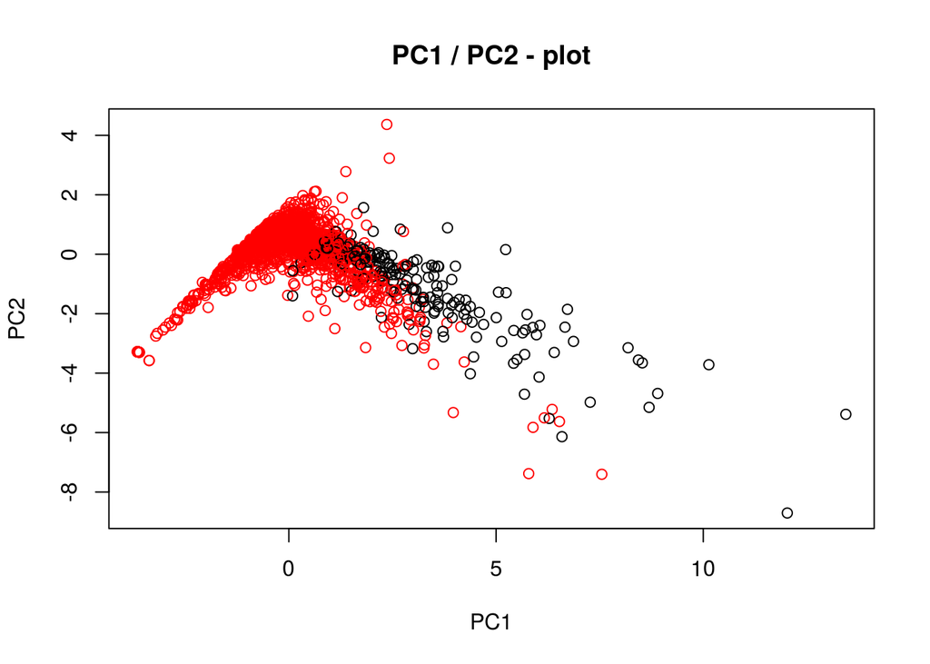

```r
set.seed(101)
km <- kmeans(data_region3[,1:7], 2)
plot(data_region3.pca$x[,1],data_region3.pca$x[,2], xlab="PC1",
     ylab = "PC2",
     main = "PC1 / PC2 - plot",
     col=km$cluster)
```

```r
table(predicted=km$cluster, data_region3$Revenue)
```

```
##
## predicted FALSE TRUE
##         1   145   50
##         2  1909  299
```

This is the result I found as a result of the estimated classification of graphical data. Black dots represent online shoppers, red dots represent customers who do not shop online.

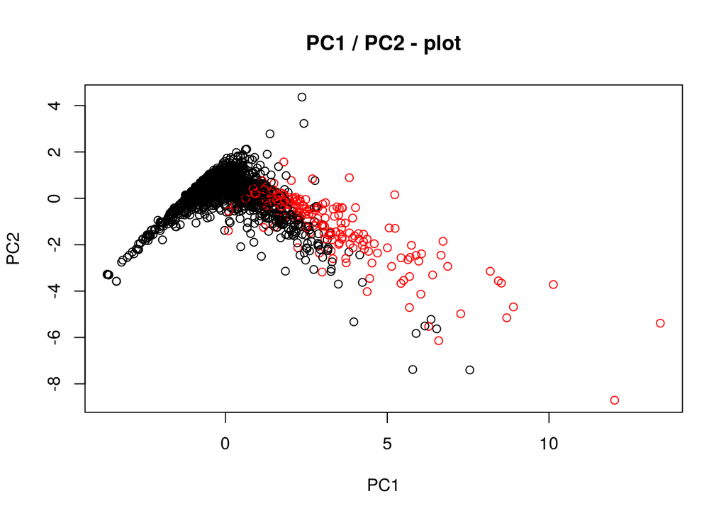

```r
set.seed(102)
km <- kmeans(data_region3[,1:7], 2)
plot(data_region3.pca$x[,1],data_region3.pca$x[,2], xlab="PC1",
     ylab = "PC2",
     main = "PC1 / PC2 - plot",
     col=km$cluster)
```

```r
table(predicted=km$cluster, data_region3$Revenue)
```

```
##
## predicted FALSE TRUE
##         1  1909  299
##         2   145   50
```

This graph is the same as the graph above, but the colors are inverted.

```r
table(predicted=km$cluster, true=data_region3$Revenue)
```

```
##          true
## predicted FALSE TRUE
##         1  1909  299
##         2   145   50
```

The difference between my estimated classification and real classes is seen in the table. It is predicted that around 2200 people do not shop, but 299 people actually shop online. Likewise, although it is estimated that about 200 people are shopping, only 50 of them is a correct guess.

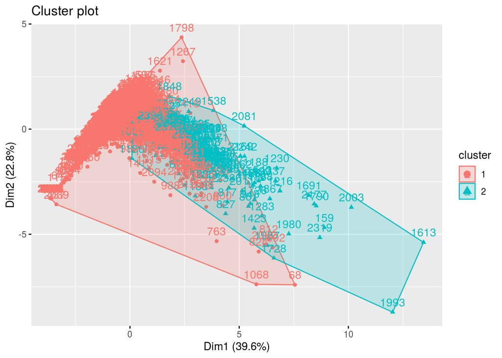

```r
km <- kmeans(data_region3[,1:7], 2)
#We can also plot clusters with fviz_cluster() function
fviz_cluster(km, data = data_region3[,1:7])
```

In the graph, the areas of the classes we estimated are shown. As can be seen, in some places, 2 fields are seen on top of each other.

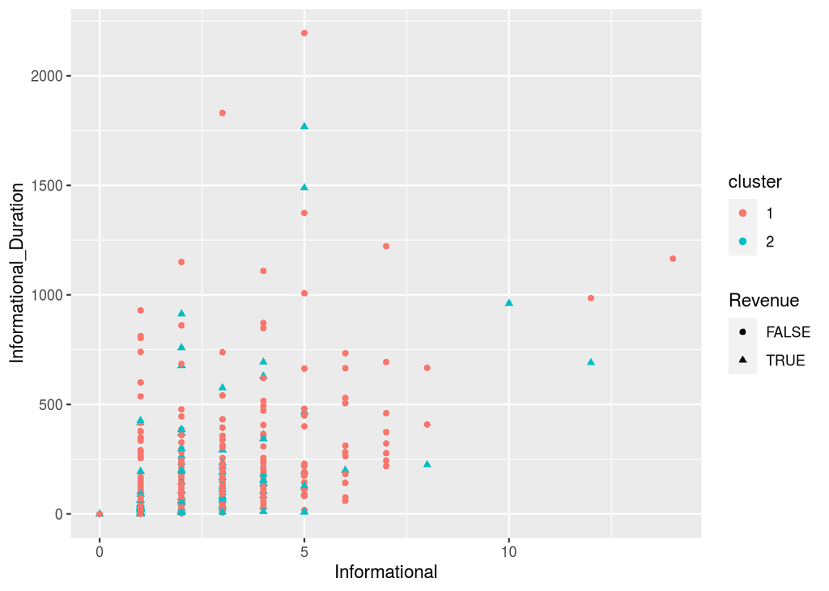

```r
data_region3 %>% select(Revenue) %>% kmeans(centers=2) -> km
customer_cluster <- data.frame(data_region3, cluster=factor(km$cluster))
ggplot(customer_cluster, aes(x=Informational, y=Informational_Duration, color=cluster, shape=Revenue)) + geom_point()
```

The graph shows how many online shopping sites customers click and the average time they spend on these sites.

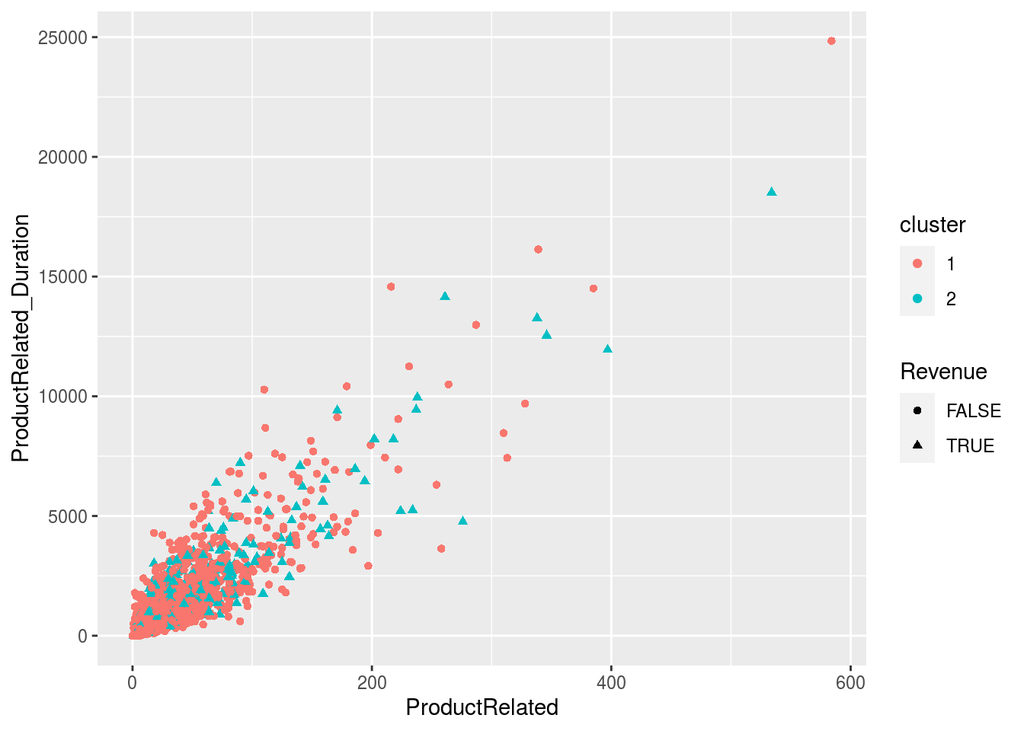

```r
data_region3 %>% select(Revenue) %>% kmeans(centers=2) -> km
customer_cluster <- data.frame(data_region3, cluster=factor(km$cluster))
ggplot(customer_cluster, aes(x=ProductRelated, y=ProductRelated_Duration, color=cluster, shape=Revenue)) + geom_point()
```

The graph of how many products the customers clicked and the average time spent on these products can be seen.

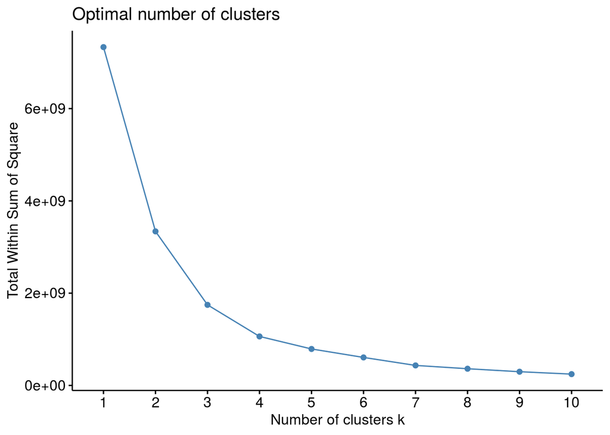

```r
#Agglomerative hierarchical clustering (HC)---hclust function
distance <- dist(data_region3[,1:7], method="euclidean")
#Elbow method can also be used here
fviz_nbclust(data_region3[,1:7], FUN = hcut, method = "wss")
```

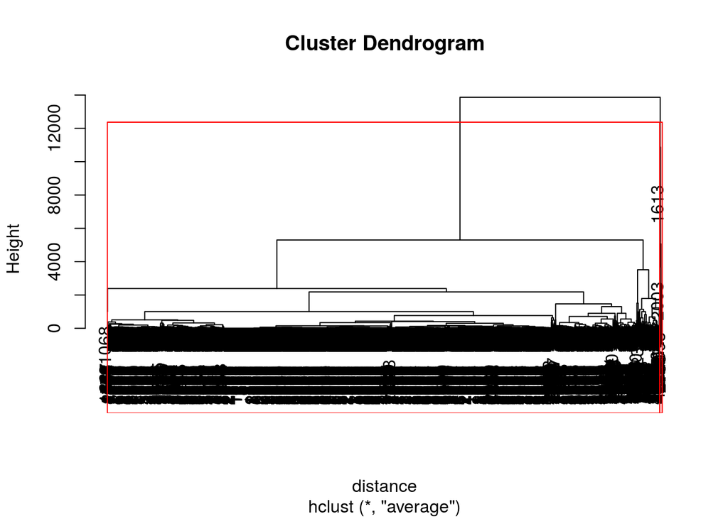

```r
hier <- hclust(distance, method="average")
plot(hier)
rect.hclust(hier, k=2, border="red")
```

```r
hier_cut <- cutree(hier, 2)
table(predicted=hier_cut, true=data_region3$Revenue)
```

```
##          true
## predicted FALSE TRUE
##         1  2048  344
##         2     6    5
```

When we apply a different clustering method, we see a very different result from the first method. It was estimated that 2400 customers did not shop online, but the 344 people in the estimate were actually online shoppers. Of the 11 people thought to shop online, 6 were actually customers who did not shop online.